# Mapping Countries and Regions in R

Clara Bicalho and Valeria Gracia Olvera

2026-02-16

# Introduction

This short tutorial shows you how to:

1. Plot the polygon (or borders) of a country.
2. Plot subnational administrative regions (e.g., states or municipalities).
3. Add points to a map using specific geographic coordinates.
4. Shade regions based on a given statistic.

We will use the `sf`, `rnaturalearth`, `dplyr`, and `ggplot2` packages.

```r
# Install packages if needed
# install.packages(c("sf", "rnaturalearth", "rnaturalearthdata", "ggplot2", "dplyr"))

library(sf)
library(rnaturalearth)
library(rnaturalearthdata)
library(ggplot2)
library(dplyr)
```

# 1. Plot a Country Polygon

## Step 1: Specify the country

You can change the country name below.

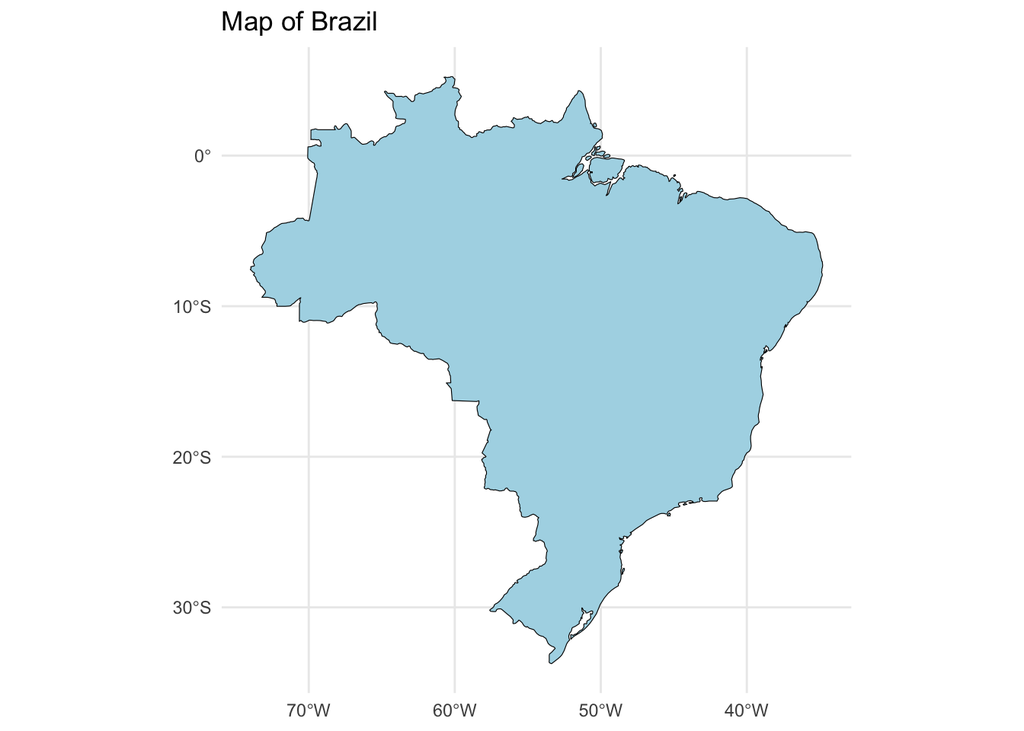

```r
country_name <- "Brazil"   # Change this to any country name

# Download country boundaries
world <- ne_countries(scale = "medium", returnclass = "sf")

# Filter for chosen country
country_sf <- world %>%
  filter(admin == country_name)

# Plot
ggplot(data = country_sf) +
  geom_sf(fill = "lightblue", color = "black") +
  theme_minimal() +
  labs(title = "Map of Brazil") # You can change the title
```

# 2. Plot Subnational Administrative Regions

We now download first-level administrative units (e.g., states or provinces).

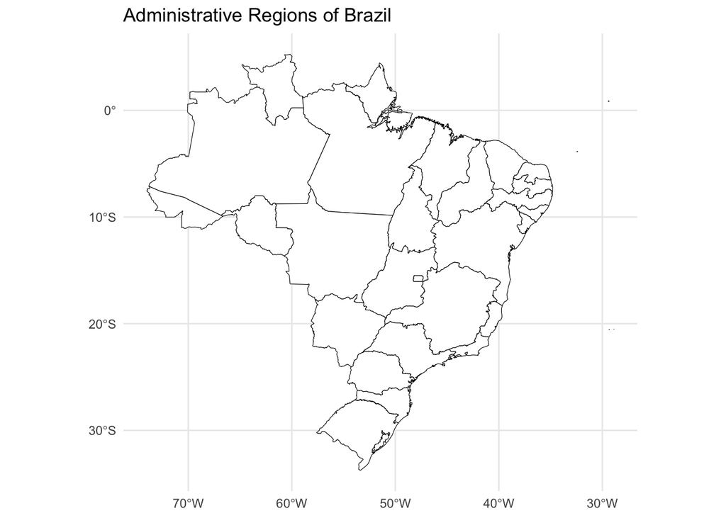

```r
# You may need to use the code below to install the package
# install.packages(
#   "rnaturalearthhires",
#   repos = "https://ropensci.r-universe.dev",
#   type = "source"
# )

# Download first-level administrative regions
regions <- ne_states(country = country_name, returnclass = "sf")

# Plot regions
ggplot(data = regions) +
  geom_sf(fill = "white", color = "black") +
  theme_minimal() +
  labs(title = paste("Administrative Regions of", country_name))
```

# 3. Plot Municipalities within a Country

## Step 1: Download the required data

First we need to download the country-specific data. You can access the data from many sources, including official country ones. Here we use [GeoBoundaries](https://www.geoboundaries.org/simplifiedDownloads.html).[^1]

Note: ADM0 = country boundaries, ADM1 = first-level administrative units (e.g., states), ADM2 = second-level administrative units (e.g., municipalities).

In the code below, we use Brazil’s municipal borders. You can replace the path (`dsn`) and `layer` with your own data.

```r
# Load the country boundary shapefile (replace with your own path)
brz_adm2 <- st_read(
  dsn = "data/geoBoundaries-BRA-ADM2-all", # path of the folder
  layer = "geoBoundaries-BRA-ADM2_simplified") # name of the shapefile (without .shp extension)
```

## Step 2: Select region/municipality you want to display

```r
# Select the municipalities you want to plot
munic <- brz_adm2 %>%
  filter(shapeName %in% c("Cavalcante",
                          "Teresina de Goiás",
                          "Monte Alegre de Goiás"))
```

## Step 3: Plot the selected municipalities

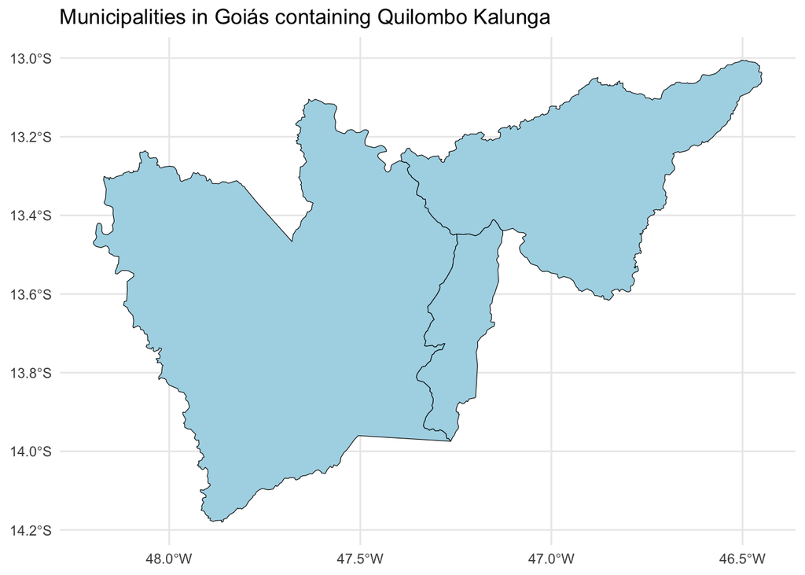

```r
# Plot
ggplot(data = munic) +
  geom_sf(fill = "lightblue", color = "black") +
  theme_minimal() +
  # Change your title name
  labs(title = "Municipalities in Goiás containing Quilombo Kalunga")
```

You can also remove the fill color to just show borders.

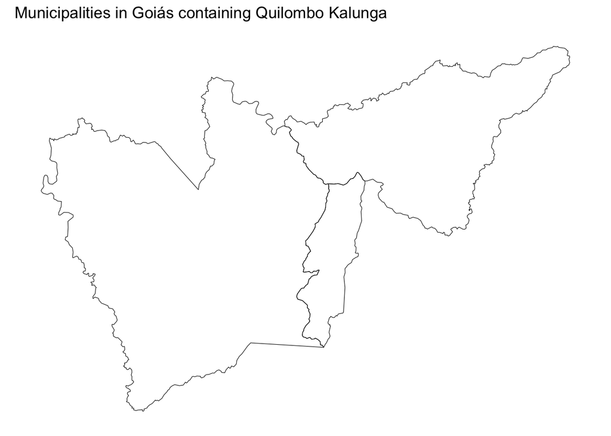

```r
ggplot(data = munic) +
  geom_sf(fill = NA, color = "black") +
  theme_minimal() +
  # Change your title name
  labs(title = "Municipalities in Goiás containing Quilombo Kalunga") +
  # Add municipality name labels
  theme_minimal() +
  theme(axis.line = element_blank(),
        axis.text = element_blank(),
        axis.ticks = element_blank(),
        panel.grid.major = element_blank(),
        panel.grid.minor = element_blank())
```

And add municipality names:

```r
centroids <- st_centroid(munic)
```

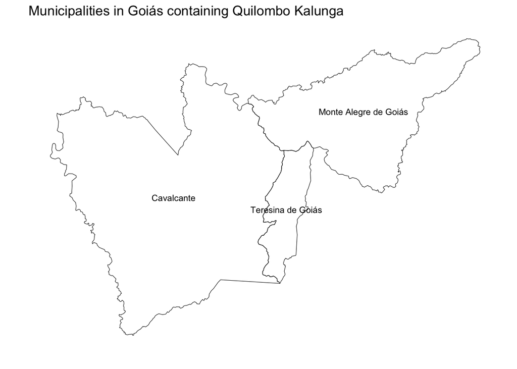

```r
coords <- st_coordinates(centroids)

munic$X <- coords[,1]
munic$Y <- coords[,2]

mun_map <- ggplot(data = munic) +
  geom_sf(fill = NA, color = "black") +
  theme_minimal() +
  # Change your title name
  labs(title = "Municipalities in Goiás containing Quilombo Kalunga") +
  # Add municipality name labels
  geom_text(aes(x = X, y = Y, label = shapeName), size = 3) +
  theme_minimal() +
  theme(axis.line = element_blank(),
        axis.text = element_blank(),
        axis.ticks = element_blank(),
        panel.grid.major = element_blank(),
        panel.grid.minor = element_blank()) +
  labs(x = "", y = "") # Remove axis labels

mun_map
```

# 4. Create an Inset Map (Combine zoomed-in map with “zoomed-out” map)

Often you want:

- A detailed map of one municipality (zoomed in), AND
- A small inset map showing where that municipality is located within the country.

This can be done by creating two maps and combining them.

We will use the `patchwork` package to combine plots.

```r
# install.packages("patchwork")  # if needed
library(patchwork)
```

## Step 1: Create the Zoomed-In Map

```r
zoom_map <- mun_map +
  labs(title = "Selected Municipalities")
```

## Step 2: Create a Context Map

Highlight the selected municipality inside the country.

```r
context_map <- ggplot() +
  geom_sf(data = country_sf, fill = "gray90", color = "white") +
  geom_sf(data = munic, fill = "red", color = "black") +
  theme_void()
```

## Step 3: Combine the Two Maps

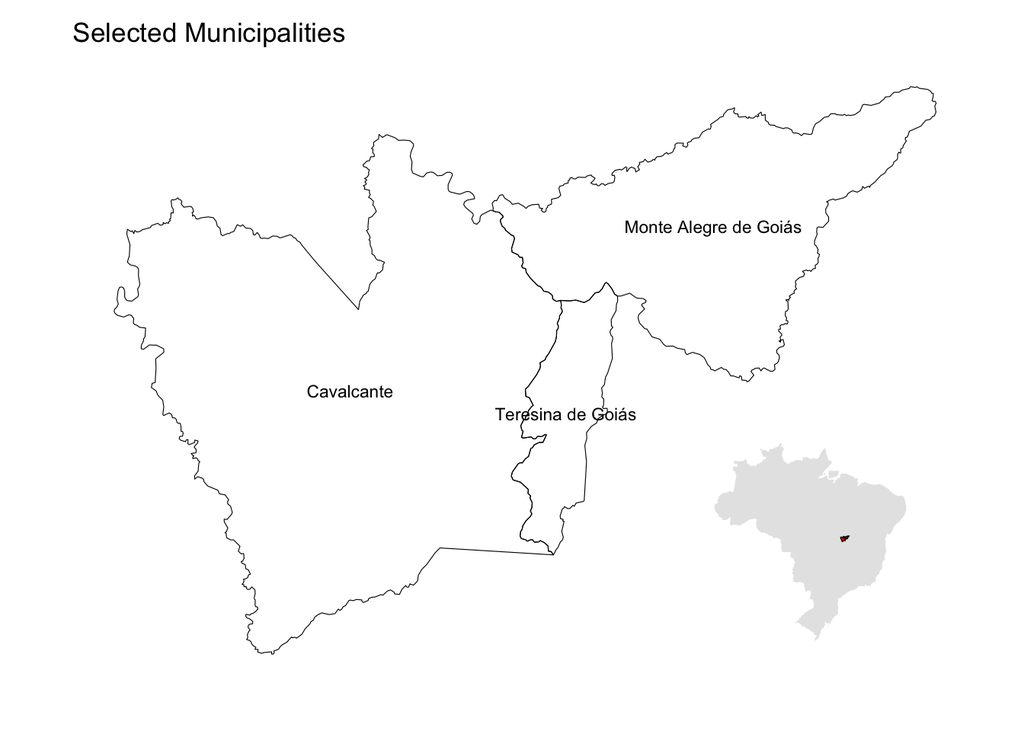

```r
final_map <- zoom_map +
  inset_element(context_map,
                left = 0.65, bottom = 0.05,
                right = 0.98, top = 0.4)

final_map
```

The arguments (`left`, `bottom`, `right`, `top`) control where the inset appears. Adjust them to reposition the small map.

## How do I export the maps?

```r
ggsave(plot = last_plot(), # last plot generated
       "map.png", # the file path to export your plot to. Here it saves on the current directory. You can run `getwd()` on the console to see what folder you are in.
       width = 8, height = 6) # change the proportions of your map
```

# 5. Add Points with Specific Coordinates

You can add specific locations (e.g., cities, survey sites, events).

## Step 1: Create a data frame of points

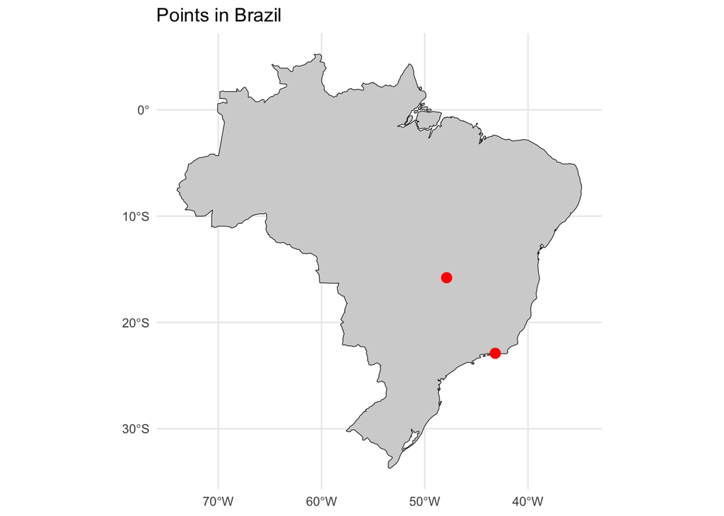

```r
# Example coordinates (replace with your own)
points_df <- data.frame(
  name = c("Location A", "Location B"),
  lon = c(-47.8825, -43.1729),
  lat = c(-15.7942, -22.9068)
)

# Convert to sf object
points_sf <- st_as_sf(points_df,
                      coords = c("lon", "lat"),
                      crs = 4326)

# Plot map with points
ggplot() +
  geom_sf(data = country_sf, fill = "lightgray", color = "black") +
  geom_sf(data = points_sf, color = "red", size = 3) +
  theme_minimal() +
  labs(title = paste("Points in", country_name))
```

Make sure your coordinates are in longitude (x) and latitude (y) format using the WGS84 coordinate system (EPSG:4326).

# 6. Shade Regions Based on a Statistic

Suppose you have a statistic for each administrative region (e.g., population, unemployment, rainfall).

## Step 1: Create example data

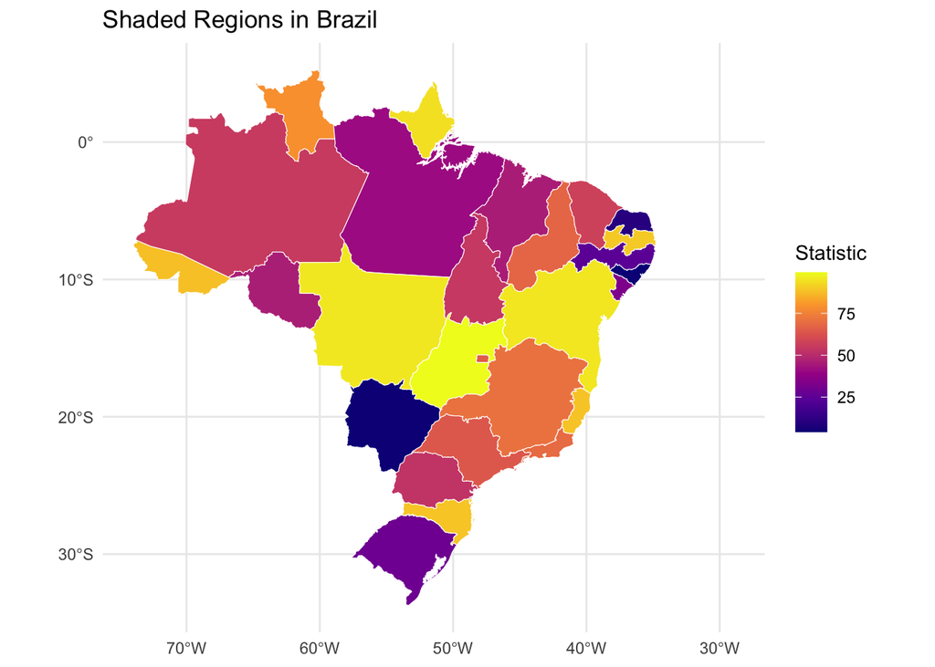

```r
# Create example statistic
set.seed(123)

regions_data <- regions %>%
  mutate(stat_value = runif(n(), min = 0, max = 100))

# Plot shaded map
ggplot(regions_data) +
  geom_sf(aes(fill = stat_value), color = "white") +
  scale_fill_viridis_c(option = "plasma") +
  theme_minimal() +
  labs(title = paste("Shaded Regions in", country_name),
       fill = "Statistic")
```

## Using Your Own Data

If you have a separate dataset with statistics, you must merge it with the spatial object.

Example structure:

```r
my_data
# region_name | value
```

Merge example:

```r
regions_data <- regions %>%
  left_join(my_data, by = c("name" = "region_name"))
```

Then plot using `aes(fill = value)`.

# Summary

In this tutorial, you learned how to:

- Download and plot country boundaries.
- Plot subnational administrative regions.
- Add point data using coordinates.
- Shade regions based on a given statistic.

You can adapt this template by:

- Changing `country_name` and downloading the files specific to your country and administrative region of choice.
- Replacing the example coordinates.
- Merging real statistical data.
[^1]: Runfola D, Anderson A, Baier H, Crittenden M, Dowker E, Fuhrig S, et al. (2020) geoBoundaries: A global database of political administrative boundaries. PLoS ONE 15(4): e0231866. https://doi.org/10.1371/journal.pone.0231866.